# Guide de la Visionneuse

[figure not shown]

[figure not shown]

# Visionneuse 094

Guide d’utilisation — octobre 2026

Projeter un diaporama et faire participer la salle depuis les téléphones : questionnaires, nuages de mots, diapositives à consulter.

Téléchargement, guides et nouveautés : **mission-numerique-94.web.app**

## 1. À quoi sert la Visionneuse

La Visionneuse remplace le mode « présentateur » de PowerPoint pour une formation ou une réunion où l’on veut **faire participer le public**. Sur votre ordinateur, vous voyez la diapositive, vos commentaires, la suite et le rythme de la séance. Sur le vidéoprojecteur, la salle voit la diapositive. Et sur leur téléphone, les participants :

- suivent les diapositives que vous leur ouvrez, et peuvent les télécharger ;
- répondent aux questionnaires et aux nuages de mots que vous lancez ;
- voient les résultats quand vous les révélez.

Les participants n’installent rien et ne donnent aucune identité : ils scannent un QR code, c’est tout.

[figure not shown]

L’écran de la Visionneuse : le plan à gauche, l’aperçu et les commentaires au centre, la vue présentateur à droite.

L’écran se lit en trois colonnes :

- **à gauche, le plan** de la séance : diapositives, questions, pause ;
- **au centre, l’aperçu** de ce que vous projetez, avec vos commentaires dessous ;
- **à droite, la vue présentateur** : chronomètre, minuteur, ce que voient les autres, la diapositive suivante, les réponses en direct.

En haut à droite, l’interrupteur soleil / lune passe la Visionneuse en **mode clair** (par défaut) ou en **mode sombre**, et le bouton **?** ouvre ce guide ou la **visite guidée** de l’écran.

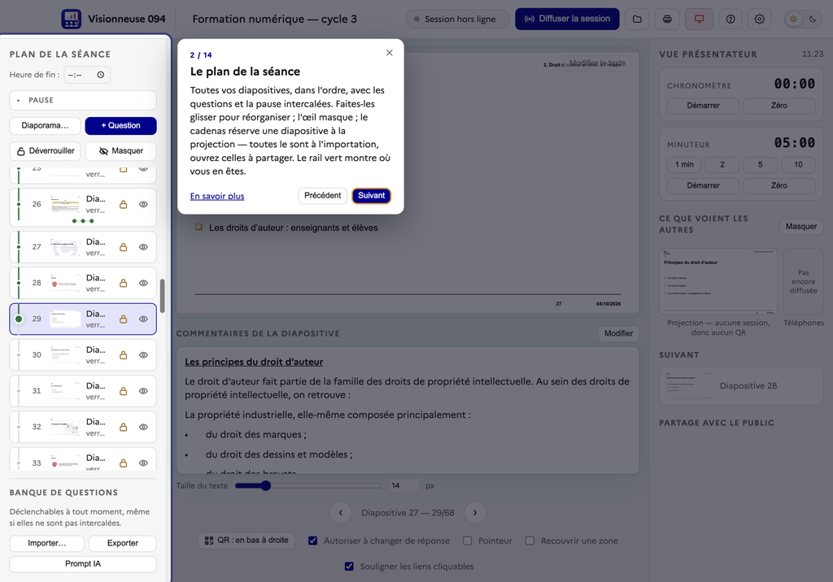

La visite guidée éclaire chaque zone de l’écran, une à une.

## 2. Installation et mises à jour

La Visionneuse se télécharge sur **mission-numerique-94.web.app**, pour Mac et pour Windows. La page donne aussi la dernière version, ses nouveautés, ce guide en PDF et la Moulinette EvNat 094.

**Sur Mac (Apple Silicon)** : ouvrez le fichier `Visionneuse-<version>-mac-arm64.dmg` et glissez l’application dans le dossier **Applications**. Au premier lancement, faites **clic droit → Ouvrir** (l’application n’est pas signée par Apple), puis confirmez.

**Sur Windows** : lancez `Visionneuse-<version>-win-x64.exe`. Si SmartScreen s’affiche, cliquez sur « Informations complémentaires » puis « Exécuter quand même ».

Pour convertir les diaporamas PowerPoint, la Visionneuse utilise **LibreOffice** (gratuit) s’il est installé, sinon PowerPoint. Les fichiers PDF n’ont besoin de rien.

**Mises à jour** : la Visionneuse vérifie elle-même, au démarrage puis toutes les quatre heures, si une nouvelle version existe. Elle la télécharge discrètement ; un bouton vert **« Version … prête »** apparaît alors en haut. Vous choisissez : **Installer et relancer**, ou **Installer en quittant**. Elle n’installe jamais rien pendant une projection ou une diffusion. Chaque mise à jour est signée : l’application refuse tout fichier qui ne viendrait pas de son auteur. Dans les **Réglages**, « Rechercher une mise à jour » vérifie tout de suite.

Les séances enregistrées avec une version ancienne s’ouvrent toujours dans une version récente.

## 3. Préparer la séance

### Importer un diaporama

Cliquez sur **Diaporama…** (ou glissez le fichier sur la fenêtre). Formats acceptés : PowerPoint (`.pptx`, `.ppt`), OpenDocument (`.odp`), Keynote (`.key`), PDF. La première importation d’un gros diaporama prend environ une minute ; les suivantes sont immédiates.

La Visionneuse reprend :

- les **animations** : chaque clic d’apparition devient une étape, comme dans PowerPoint ;
- les **vidéos et sons**, lus sur le vidéoprojecteur ;
- les **liens** cliquables des diapositives ;
- vos **commentaires**, avec leur mise en forme (gras, couleurs, puces, listes numérotées).

Enregistrez la séance (**⌘ S** / **Ctrl S**) : le fichier `.qcm` garde le plan, les questions, les réglages et, si vous le souhaitez, le diaporama lui-même.

### Ajouter un questionnaire ou un nuage de mots

Le bouton **+ Question** ouvre l’éditeur. Deux types :

- **Questionnaire** : un énoncé, jusqu’à huit propositions, et, si vous le voulez, la bonne réponse (qu’on pourra révéler à la fin) ;
- **Nuage de mots** : chaque participant propose un à cinq mots ; les plus cités grossissent.

La question rejoint le plan, après l’élément affiché : faites-la glisser où vous voulez. Les questions retirées du plan restent dans la **banque de questions**, en bas à gauche, d’où on peut les relancer à tout moment.

Pour préparer beaucoup de questions d’un coup : **Importer…** lit un fichier CSV (tableur), **Exporter** en produit un, et **Prompt IA** donne une consigne toute prête pour faire rédiger un questionnaire au bon format par une intelligence artificielle.

### Reprendre les questions écrites dans le diaporama

Si votre diaporama contient déjà des diapositives de questions (un énoncé avec un point d’interrogation et des propositions A, B, C…), la Visionneuse les repère à l’importation et vous propose de les transformer en vrais questionnaires. Vérifiez-les avant la séance : la « réponse attendue » est tirée des commentaires quand ils l’indiquent.

### Organiser le plan

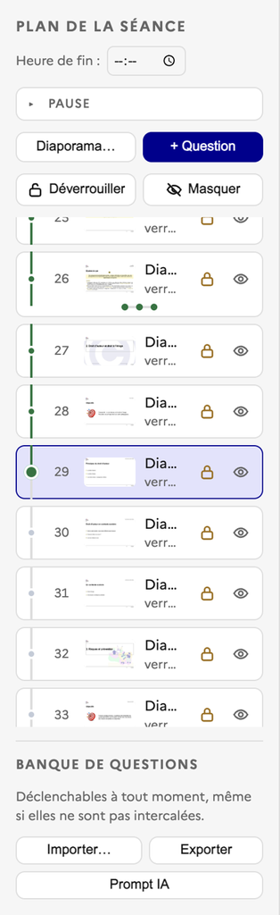

Le plan : le rail vert montre la progression, l’œil masque, le cadenas réserve à la projection.

### Placer la pause

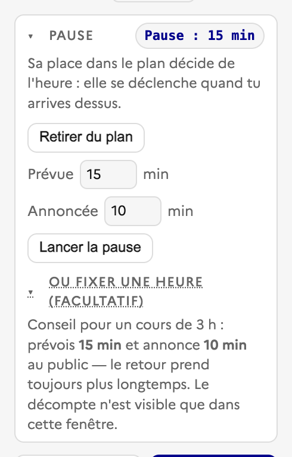

Le réglage de la pause, en haut du plan.

**La façon conseillée** : cliquez sur **Placer dans le plan**, puis faites glisser la ligne « Pause » entre les deux diapositives voulues. Son heure se déduit de sa place et du rythme de la séance. Quand vous arrivez dessus, **la pause se déclenche** : l’heure de reprise est fixée et ne bouge plus, même si vous passez à la diapositive suivante ou revenez en arrière. Seul **Réinitialiser la pause** efface ces heures.

**Ou bien**, ouvrez « Ou fixer une heure » et saisissez l’heure de la pause : elle se place alors toute seule dans le plan, là où vous devriez en être à cette heure-là, et s’y recale si vous prenez de l’avance ou du retard. Elle ne se déclenche pas d’elle-même : cliquez sur **Lancer la pause** le moment venu. La faire glisser à la main revient au premier mode.

Deux durées : la durée **prévue** (pour vous et pour le calcul du rythme) et la durée **annoncée** à la salle. Pour un cours de trois heures, prévoyez 15 minutes et annoncez-en 10 : le retour prend toujours plus longtemps.

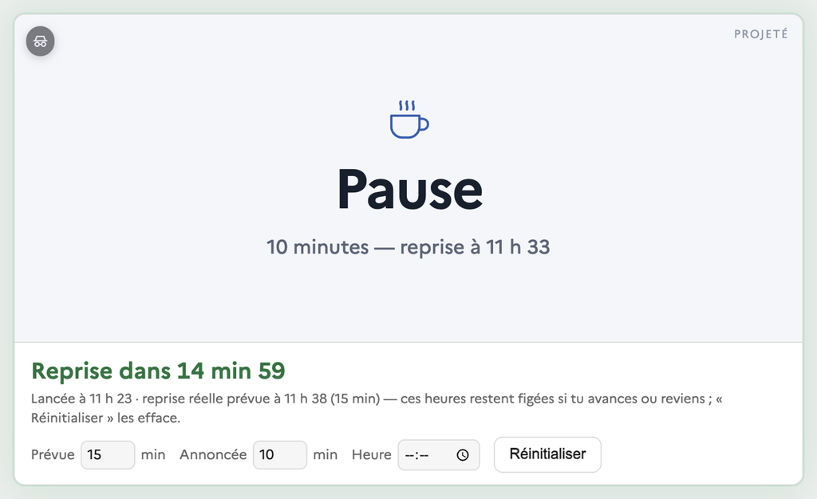

Pendant la pause, l’écran central montre ce que voit la salle, le vrai décompte, et permet de modifier les durées.

### Fixer l’heure de fin et suivre le rythme

Indiquez l’**heure de fin** en haut du plan. Le rail de gauche devient alors un « métro » : l’étape où vous **devriez** être clignote, dans la couleur de votre rythme — vert à l’heure, bleu en avance, jaune, orange puis rouge en retard. Un halo de la même couleur entoure discrètement l’aperçu central. L’indicateur donne le temps à consacrer à chaque étape restante pour finir à l’heure, pause comprise.

### Retoucher les commentaires

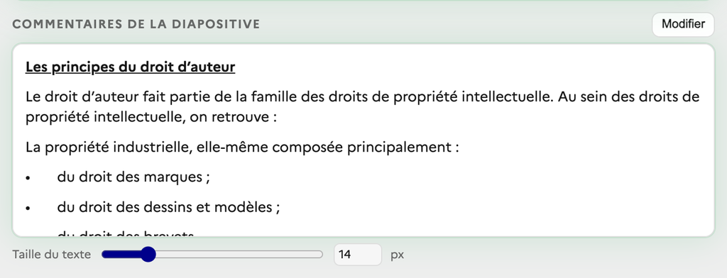

Les commentaires du PowerPoint, avec leur mise en forme.

Les commentaires s’affichent comme dans le volet « Commentaires » de PowerPoint. Le curseur **Taille du texte** les agrandit pour les lire de loin. **Modifier** ouvre un éditeur (gras, italique, souligné, listes, couleurs) : la retouche est gardée dans la séance, le fichier PowerPoint n’est jamais modifié. **Original** revient au commentaire du diaporama.

### Imprimer le déroulé

Le bouton **imprimante** compose un PDF de la séance : chaque diapositive en petit avec ses commentaires, les questionnaires avec leur réponse attendue, la pause. Réglez la taille du texte et des captures, choisissez ce qu’il faut inclure, vérifiez l’aperçu, enregistrez.

## 4. Animer

### Diffuser la session

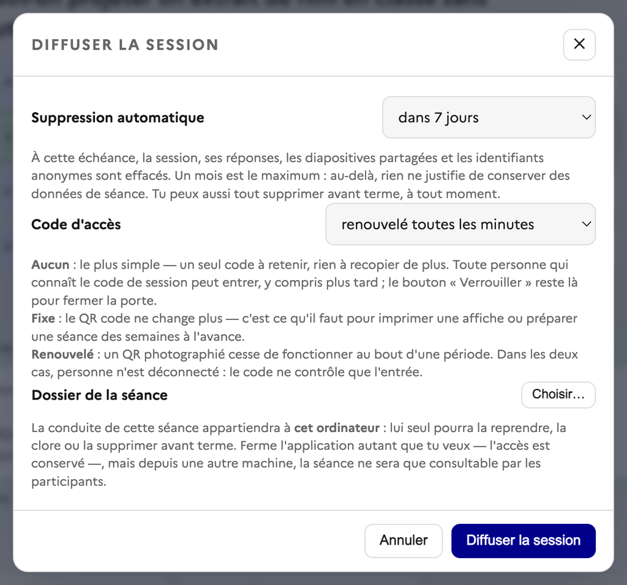

La fenêtre « Diffuser la session ».

**Diffuser la session** crée la séance en ligne : un **code** de six caractères et un **QR code**, que la projection affiche. Les participants le scannent avec l’appareil photo de leur téléphone.

Par défaut, un **PIN** (code d’accès) s’affiche sous le QR et change toutes les minutes : une photo du QR prise la veille, ou transmise hors de la salle, ne permet pas d’entrer. Un participant déjà entré n’est jamais déconnecté. C’est la base de données elle-même qui vérifie ce code : on ne peut pas répondre sans lui.

**Arrêter la diffusion** ferme la porte : plus aucun QR ni PIN ne permet d’entrer. Vous pouvez laisser les diapositives consultables après le cours, jusqu’à la date d’expiration.

### Projeter

**Projeter** ouvre la projection en plein écran sur le vidéoprojecteur (choisissez l’écran dans les Réglages si vous en avez plusieurs). **Échap** en sort. **B** passe à un écran noir, pour ramener l’attention vers vous. L’emplacement et la taille du QR code se règlent avec le bouton **QR** sous l’aperçu.

### Lancer, mettre en pause, révéler un sondage

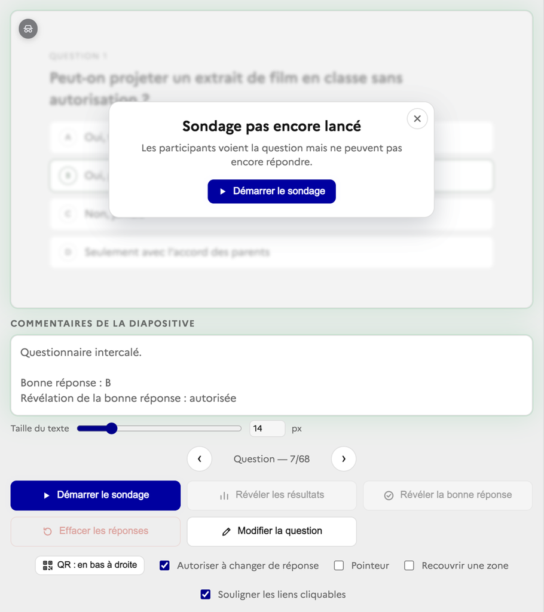

Un sondage pas encore lancé : un voile le rappelle, le bouton « Démarrer » invite au clic.

Quand vous arrivez sur un questionnaire ou un nuage, la question s’affiche partout, mais **personne ne peut encore répondre**. Un voile sur l’aperçu le rappelle ; la croix le réduit à un petit bandeau.

1. **Démarrer le sondage** ouvre les réponses. Le bouton clignote tant qu’il n’a jamais été lancé.
2. **Mettre en pause** les ferme ; **Reprendre** les rouvre.
3. **Révéler les résultats** affiche les barres (ou le nuage) sur la projection et les téléphones ; un second clic les masque.
4. **Révéler la bonne réponse** la met en évidence, si vous l’avez autorisé dans la question.
5. **Effacer les réponses** remet les compteurs à zéro et laisse chacun revoter.

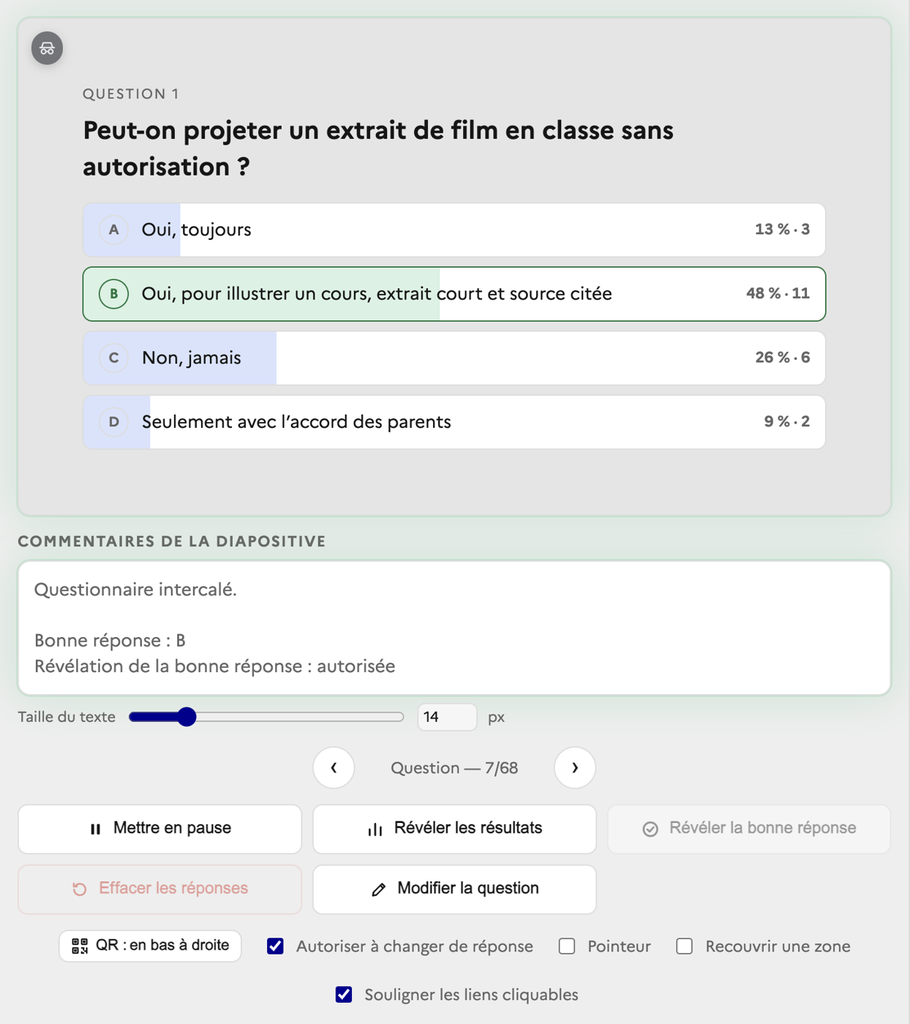

Sondage en cours : les pourcentages en direct ne sont visibles que de vous.

Les pourcentages en direct de l’aperçu central ne sont visibles **que de vous** : la salle ne voit rien avant que vous révéliez. Si vous revenez sur un sondage déjà fait, vous le retrouvez tel que vous l’aviez laissé.

La touche **P** met en pause ou reprend un sondage **déjà lancé**. Aucune touche ne lance un sondage par erreur : la barre d’espace avance à l’élément suivant, comme dans PowerPoint, et le premier lancement se fait toujours d’un clic sur « Démarrer le sondage ».

### Modérer un nuage de mots

Les mots arrivent en direct dans l’aperçu central, visibles de vous seul. Survolez un mot et cliquez sur sa **croix** pour le bannir : il disparaît de la projection et des téléphones, même si d’autres le proposent ensuite. Les mots bannis restent listés sous l’aperçu, d’où vous les rétablissez d’un clic. Dans la colonne de droite, glisser un mot sur un autre les **fusionne** (synonymes, fautes de frappe).

### Voir ce que voient la salle et les téléphones

[figure not shown]

« Ce que voient les autres » : la projection et l’écran des téléphones, côte à côte.

L’aperçu central est **privé** : le badge en haut à gauche le rappelle. Dans la colonne de droite, **Ce que voient les autres** montre, côte à côte, la projection et l’écran d’un téléphone. Survolez la projection pour la voir en grand.

La vignette **Suivant** annonce l’élément qui vient ; survolez-la pour le voir en grand avec son commentaire, et faites défiler ce commentaire à la molette sans bouger la souris.

### Pointeur, vidéos et corrections à la volée

- **Pointeur** : cochez-le, puis cliquez sur l’aperçu ; une pastille jaune apparaît au même endroit sur la projection (et chez les participants).
- **Vidéos et sons** : sous l’aperçu, chaque média a sa barre de lecture (lire, pause, ±10 s, début). Ils démarrent tout seuls si l’animation PowerPoint le prévoit.
- **Recouvrir une zone** : tracez un rectangle sur l’aperçu pour masquer une coquille ou un chiffre faux, et réécrivez par-dessus ; le texte apparaît sur la diapositive au fur et à mesure que vous l’écrivez. Une zone posée se **déplace** en la faisant glisser, se **redimensionne** par sa poignée bleue (coin en bas à droite), et se modifie d’un simple clic. Le fichier d’origine n’est pas modifié.
- **Modifier le texte** (PowerPoint et OpenDocument) : corrige le texte dans une copie du fichier, en gardant la mise en forme.

### Raccourcis clavier

| Touche | Action |
| --- | --- |
| → ↓ Espace, Page suivante | Étape ou élément suivant |
| ← ↑ Page précédente | Étape ou élément précédent |
| P | Mettre en pause / reprendre un sondage déjà lancé |
| B | Écran noir sur la projection |
| Échap | Fermer une fenêtre ; sortir de la projection |
| F1 | Ouvrir ce guide |
| ⌘ Entrée / Ctrl Entrée | Lancer la projection |
| ⌘ ⇧ R / Ctrl ⇧ R | Révéler les résultats |
| ⌘ S / Ctrl S | Enregistrer la séance |

## 5. Après la séance

### Arrêter la diffusion, effacer les données

Les réponses sont **anonymes** : un participant n’est qu’un identifiant jetable, sans nom ni adresse. Personne d’autre que vous ne peut lire les réponses une à une ; la salle ne voit que les résultats que vous révélez.

Chaque session a une **date d’expiration** (sept jours par défaut, réglable à l’ouverture). Les sessions expirées sont effacées automatiquement au démarrage de la Visionneuse ; **Supprimer**, en haut, efface tout de suite la session en cours, ses réponses et les diapositives partagées.

## 6. Questions fréquentes

**Les participants peuvent-ils changer de réponse ?** Oui, par défaut, tant que le vote est ouvert. Décochez « Autoriser à changer de réponse » sous l’aperçu pour figer le premier choix.

**Un participant ne peut pas répondre.** Le sondage est-il démarré (le bouton ne doit plus clignoter) ? Le participant est-il bien entré avec le PIN affiché ? S’il a scanné un vieux QR, qu’il scanne celui de la projection.

**La salle voit les résultats trop tôt.** Impossible : avant « Révéler », seul le nombre de réponses est publié.

**J’ai avancé par erreur pendant la pause.** Revenez dessus : l’heure de reprise n’a pas changé. Pour annuler la pause, utilisez **Réinitialiser la pause**.

**Les commentaires ne sont pas mis en forme.** Seuls les fichiers PowerPoint `.pptx` portent la mise en forme ; un PDF ou un Keynote n’a que le texte.

**L’application ne se met pas à jour sur Mac.** Elle doit être dans le dossier Applications, et non lancée depuis l’image disque (`.dmg`).

**Je veux tout voir en grand au vidéoprojecteur.** Choisissez l’écran dans les Réglages, puis **Projeter**. Sur un seul écran, la projection prend tout l’écran : **Échap** pour revenir.

## 7. Données personnelles (RGPD)

**La Visionneuse ne collecte aucune donnée personnelle sur les participants.** Elle a été conçue pour que rien de ce qui identifie une personne ne quitte la salle.

**Ce qui reste sur votre ordinateur, et seulement là** :

- vos diaporamas, leur conversion en images (faite sur votre poste, par LibreOffice ou PowerPoint), vos commentaires et leurs retouches, les zones recouvertes ;
- vos séances (fichiers `.qcm`), le déroulé imprimé, les exports ;
- vos préférences (thème, taille du texte…).

Rien de cela n’est envoyé où que ce soit tant que vous ne diffusez pas une session.

**Ce qui passe en ligne pendant une diffusion, et seulement pendant celle-ci** :

- la question en cours et, si vous les ouvrez au public, les images des diapositives que vous avez choisi de partager ;
- les **réponses anonymes** : une lettre choisie, ou les quelques mots proposés dans un nuage. Un participant n’est qu’un identifiant technique tiré au hasard sur son téléphone : ni nom, ni adresse, ni numéro, ni compte, ni géolocalisation ;
- le code de la session et le code d’accès du moment.

Ces données sont hébergées par Google Firebase **dans l’Union européenne** (région « eur3 »), protégées par des règles d’accès : seul l’animateur lit les réponses une à une, le public ne voit que les résultats révélés. Chaque session porte une **date d’expiration** (sept jours par défaut) : elle est alors effacée, avec ses réponses et ses images ; « Supprimer » l’efface aussitôt. Aucune publicité, aucun traceur, aucun profilage, aucune revente.

**L’animateur** : votre adresse électronique n’est utilisée que si vous choisissez de retrouver vos séances sur un autre poste ; elle n’est jamais visible des participants, et la session n’en garde qu’une empreinte chiffrée.

**Un conseil** : dans un nuage de mots, les participants écrivent librement. Rappelez-leur de ne pas saisir de nom ni d’information personnelle ; vous pouvez de toute façon bannir un mot d’un clic.

**Mises à jour** : la Visionneuse consulte régulièrement la page des mises à jour pour savoir si une nouvelle version existe. Elle n’envoie aucune information sur vous ni sur vos séances.